# Data Analysis on Children’s Health

Moses Choka Onyango

2023-07-20

### INTRODUCTION

Epidemiology as a field of study, is focused on studying about the distribution and determinants of diseases in a population of a particular region. The field also aims at the development of knowledge on how to control the diseases based on insights obtained from analysis of data.

Often, the population demographics are of different structure in different regions, in this study the population of interest are children aged five years and below in the 47 counties in the Country.

### DATA

The data for this particular study comes from all the 47 counties in Kenya for periods between January 2021 and June 2023. The recorded variables includes the number of children dewormed, number of children with acute malnutrition, number of children with stunted growth, number of children with diarrhea cases, and the number of children who are underweight.The children involved in this particular study are aged five years and below.

### OBJECTIVES OF THE STUDY

#### Specific Objective

- This study aims to find the correlation between the number of diarrhea cases with the total number of children dewormed, number of children with acute malnutrition and number of children with stunted growth.
- In addition, the study aims at developing a linear regression model to study the relationship between these variables, with the total number of diarrhea cases as the response variable, and the total number of children dewormed, number of children with acute malnutrition as the independent variables.

### METHODOLOGY

In this analysis we’ll perform exploratory data analysis (EDA) on the data to gain general insights about the data, and later carry out correlation analysis and regression analysis to study the association between the dependent and independent variables.

The analysis will follow the conventional data analysis steps, including:

- Data Preparation
- Data Processing
- Data Analysis
- Data Visualization

```r
# load data
library(readr)
cema_internship_task_2023 <- read_csv("cema_internship_task_2023.csv")
head(cema_internship_task_2023,5) # prints the first 5 entries in the dataset
```

```
## # A tibble: 5 × 11
##   period county               `Total Dewormed` `Acute Malnutr…` `stunted 6-23 …`
##   <chr>  <chr>                           <dbl>            <dbl>            <dbl>
## 1 Jan-23 Baringo County                   3659                8              471
## 2 Jan-23 Bomet County                     1580               NA                1
## 3 Jan-23 Bungoma County                   6590               24               98
## 4 Jan-23 Busia County                     7564               NA              396
## 5 Jan-23 Elgeyo Marakwet Cou…             1407               NA               92
## # … with 6 more variables: `stunted 0-<6 months` <dbl>,
## #   `stunted 24-59 months` <dbl>, `diarrhoea cases` <dbl>,
## #   `Underweight 0-<6 months` <dbl>, `Underweight 6-23 months` <dbl>,
## #   `Underweight 24-59 Months` <dbl>
```

[output not shown]

```r
# Obtain the structure of the data ; this will highlight the dimension of the dataset (number of rows and columns) and the data types of each variable
str(cema_internship_task_2023)
```

```
## spc_tbl_ [1,410 × 11] (S3: spec_tbl_df/tbl_df/tbl/data.frame)
##  $ period                  : chr [1:1410] "Jan-23" "Jan-23" "Jan-23" "Jan-23" ...
##  $ county                  : chr [1:1410] "Baringo County" "Bomet County" "Bungoma County" "Busia County" ...
##  $ Total Dewormed          : num [1:1410] 3659 1580 6590 7564 1407 ...
##  $ Acute Malnutrition      : num [1:1410] 8 NA 24 NA NA 72 250 9 26 104 ...
##  $ stunted 6-23 months     : num [1:1410] 471 1 98 396 92 326 40 209 51 319 ...
##  $ stunted 0-<6 months     : num [1:1410] 34 3 154 143 71 86 13 87 6 102 ...
##  $ stunted 24-59 months    : num [1:1410] 380 NA 23 111 5 24 99 58 50 155 ...
##  $ diarrhoea cases         : num [1:1410] 2620 1984 4576 2239 2739 ...
##  $ Underweight 0-<6 months : num [1:1410] 85 41 231 251 57 141 223 140 13 139 ...
##  $ Underweight 6-23 months : num [1:1410] 739 86 315 608 104 ...
##  $ Underweight 24-59 Months: num [1:1410] 731 16 120 125 21 ...
##  - attr(*, "spec")=
##   .. cols(
##   ..   period = col_character(),
##   ..   county = col_character(),
##   ..   `Total Dewormed` = col_double(),
##   ..   `Acute Malnutrition` = col_double(),
##   ..   `stunted 6-23 months` = col_double(),
##   ..   `stunted 0-<6 months` = col_double(),
##   ..   `stunted 24-59 months` = col_double(),
##   ..   `diarrhoea cases` = col_double(),
##   ..   `Underweight 0-<6 months` = col_double(),
##   ..   `Underweight 6-23 months` = col_double(),
##   ..   `Underweight 24-59 Months` = col_double()
##   .. )
##  - attr(*, "problems")=<externalptr>
```

Looking at the results from the str() function above, we realize that the data set has 1410 rows and 11 columns with the variables having different data types.

Next step we will check if the data has any missing values then obtain its summary which will basically give us different measures and distributions.

```r
# Check for missing values in the columns
any(is.na(cema_internship_task_2023))
```

```
## [1] TRUE
```

Using the above function we find out that there are some missing values in the dataset, we can break this down to findout the sum of missing values in each column

```r
#Sum of missing values in each column
colSums(is.na(cema_internship_task_2023))
```

```
##                   period                   county           Total Dewormed
##                        0                        0                        0
##       Acute Malnutrition      stunted 6-23 months      stunted 0-<6 months
##                      355                       11                       19
##     stunted 24-59 months          diarrhoea cases  Underweight 0-<6 months
##                       14                        0                        0
##  Underweight 6-23 months Underweight 24-59 Months
##                        0                        0
```

Next we need to find a way of dealing with these missing values, we will delete them for this case.

```r
# deleting missing values
cleaned_data <- na.omit(cema_internship_task_2023)
any(is.na(cleaned_data))
```

```
## [1] FALSE
```

Our new data set now is free from all the NA values, its time to transform the data to make it consistent, organized and easy to use.

Earlier on we noticed that the period variable was recorded as a character data type, we will need to change it to date data type

```r
# Convert period variable from character to date data type
suppressMessages(library(dplyr))
suppressMessages(library(lubridate))

custom_format = "%b-%y"

cleaned_data <- cleaned_data %>%
  mutate(date_period = parse_date_time(period, orders = custom_format) %>% as.Date()) %>%
  select(-period)

class(cleaned_data$date_period) #check the data type of the new variable
```

```
## [1] "Date"
```

```r
head(cleaned_data, 10)
```

```
## # A tibble: 10 × 11
##    county    `Total Dewormed` `Acute Malnutr…` `stunted 6-23 …` `stunted 0-<6 …`
##    <chr>                <dbl>            <dbl>            <dbl>            <dbl>
##  1 Baringo …             3659                8              471               34
##  2 Bungoma …             6590               24               98              154
##  3 Embu Cou…             3241               72              326               86
##  4 Garissa …             6751              250               40               13
##  5 Homa Bay…             4691                9              209               87
##  6 Isiolo C…              790               26               51                6
##  7 Kajiado …             7532              104              319              102
##  8 Kakamega…             8044               36              252              279
##  9 Kiambu C…             7891              183              530              385
## 10 Kilifi C…             9991               81             1690              267
## # … with 6 more variables: `stunted 24-59 months` <dbl>,
## #   `diarrhoea cases` <dbl>, `Underweight 0-<6 months` <dbl>,
## #   `Underweight 6-23 months` <dbl>, `Underweight 24-59 Months` <dbl>,
## #   date_period <date>
```

Next we’ll change the variable names to a format that is easy to work with.

```r
# rename columns to make them easy to work with
# we'll name our new data set as analysis_data

suppressMessages(library(dplyr))

analysis_data <- cleaned_data %>% rename(Total_Dewormed = `Total Dewormed`, Acute_Malnutrition = `Acute Malnutrition`, stunted_0_to_6_mths= `stunted 0-<6 months`, stunted_6_to_23_mths = `stunted 6-23 months`, stunted_24_to_59_mths = `stunted 24-59 months`, Diarrhea_cases = `diarrhoea cases`, underweight_0_to_6_mths = `Underweight 0-<6 months`, underweight_6_to_23_mths = `Underweight 6-23 months`, underweight_24_to_59_mths = `Underweight 24-59 Months`)

colnames(analysis_data) # print the new column names
```

```
##  [1] "county"                    "Total_Dewormed"
##  [3] "Acute_Malnutrition"        "stunted_6_to_23_mths"
##  [5] "stunted_0_to_6_mths"       "stunted_24_to_59_mths"
##  [7] "Diarrhea_cases"            "underweight_0_to_6_mths"
##  [9] "underweight_6_to_23_mths"  "underweight_24_to_59_mths"
## [11] "date_period"
```

```r
dim(analysis_data)
```

```
## [1] 1048   11
```

We now have a consistent data that we can work with. Our new data after cleaning has 1048 rows and 11 columns.

### Summary Statistics

Summary statistics provides us with the descriptive statistics of the data with the different measures including the measures of central tendencies, measures of distribution, and measures of dispersion.

These are important statistics as they give us general insights about the patterns in the data. For instance, we can deduce from the summary results below that the average diarrhea cases between Jan 2021 to June 2023 is 3071.

```r
# Summary about the new data set
summary(analysis_data)
```

```
##     county          Total_Dewormed   Acute_Malnutrition stunted_6_to_23_mths
##  Length:1048        Min.   :   616   Min.   :   1.0     Min.   :   1.00
##  Class :character   1st Qu.:  3060   1st Qu.:  15.0     1st Qu.:  94.75
##  Mode  :character   Median :  5447   Median :  38.5     Median : 204.00
##                     Mean   : 13014   Mean   : 122.4     Mean   : 331.03
##                     3rd Qu.:  9217   3rd Qu.: 139.5     3rd Qu.: 396.50
##                     Max.   :392800   Max.   :4123.0     Max.   :4398.00
##  stunted_0_to_6_mths stunted_24_to_59_mths Diarrhea_cases
##  Min.   :   1.0      Min.   :   2.0        Min.   :  198
##  1st Qu.:  42.0      1st Qu.:  32.0        1st Qu.: 1564
##  Median :  96.0      Median :  65.0        Median : 2354
##  Mean   : 158.3      Mean   : 136.6        Mean   : 3071
##  3rd Qu.: 180.5      3rd Qu.: 152.0        3rd Qu.: 3625
##  Max.   :7900.0      Max.   :3169.0        Max.   :15795
##  underweight_0_to_6_mths underweight_6_to_23_mths underweight_24_to_59_mths
##  Min.   :  10.0          Min.   :  35.0           Min.   :   5.0
##  1st Qu.:  98.0          1st Qu.: 335.5           1st Qu.:  76.0
##  Median : 186.5          Median : 525.5           Median : 156.0
##  Mean   : 251.4          Mean   : 769.1           Mean   : 382.2
##  3rd Qu.: 302.2          3rd Qu.: 948.5           3rd Qu.: 440.2
##  Max.   :1937.0          Max.   :5348.0           Max.   :4680.0
##   date_period
##  Min.   :2021-01-01
##  1st Qu.:2021-08-24
##  Median :2022-04-01
##  Mean   :2022-04-01
##  3rd Qu.:2022-12-01
##  Max.   :2023-06-01
```

### Diarrhea Cases

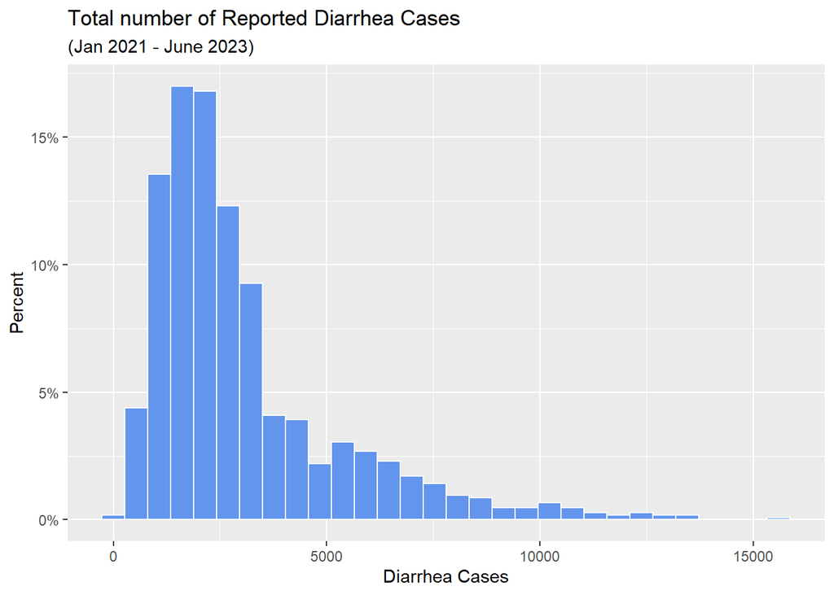

```r
# Use a histogram plot the distribution of diarrhea cases
library(ggplot2)
library(scales)
hist_plot <- ggplot(analysis_data,aes(x=analysis_data$Diarrhea_cases, y=..count../sum(..count..))) + geom_histogram(fill ="cornflowerblue",color = "white") +
  labs(title = "Total number of Reported Diarrhea Cases", subtitle ="(Jan 2021 - June 2023)", x = "Diarrhea Cases", y = "Percent" ) + scale_y_continuous(labels=percent)

hist_plot
```

Determine the highest number of diarrhea cases (Top 10 counties)

```r
Total_Diarrhea_Cases <- analysis_data %>%
  group_by(county) %>%
  select(county, Diarrhea_cases) %>%
  mutate(total_cases=sum(Diarrhea_cases)) %>%
  select(-Diarrhea_cases) %>%
  arrange(desc(total_cases)) %>%
  top_n(10) %>%
  distinct(total_cases, .keep_all = FALSE)
print(Total_Diarrhea_Cases)
```

```
## # A tibble: 44 × 2
## # Groups:   county [44]
##    county          total_cases
##    <chr>                 <dbl>
##  1 Nairobi County       304178
##  2 Turkana County       220760
##  3 Kilifi County        215511
##  4 Mandera County       189032
##  5 Nakuru County        188615
##  6 Kiambu County        155463
##  7 Kajiado County       117741
##  8 Mombasa County       116595
##  9 Machakos County      101821
## 10 Kwale County          99251
## # … with 34 more rows
```

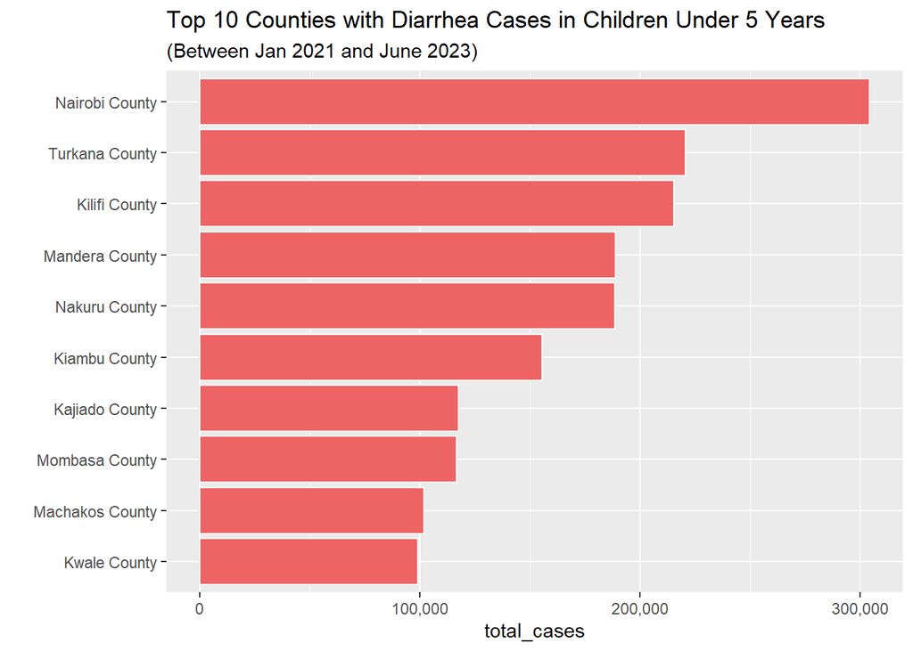

Next, we’d like to check the pattern of Diarrhea across different time period, we are interested in finding out if there have been an increase or decrease in number of diarrhea cases reported between 2021 and 2023.

```r
# Obtain the total reported diarrhea cases - yearly
yearly_diarrhea_cases <- analysis_data %>%
  select(date_period, Diarrhea_cases) %>%
  mutate(year = year(date_period)) %>%
  group_by(year) %>%
  summarise(reported_diarrhea_cases = sum (Diarrhea_cases))


yearly_diarrhea_cases
```

```
## # A tibble: 3 × 2
##    year reported_diarrhea_cases
##   <dbl>                   <dbl>
## 1  2021                 1119555
## 2  2022                 1275357
## 3  2023                  823638
```

The highest number of diarrhea cases were reported in 2022 (1275357). In 2021 the number of reported diarrhea cases was 1119555. In 2023 the reported cases thus far is 823638.

We can plot the result on a line graph to show the trend. We will need to convert the year to date data type first.

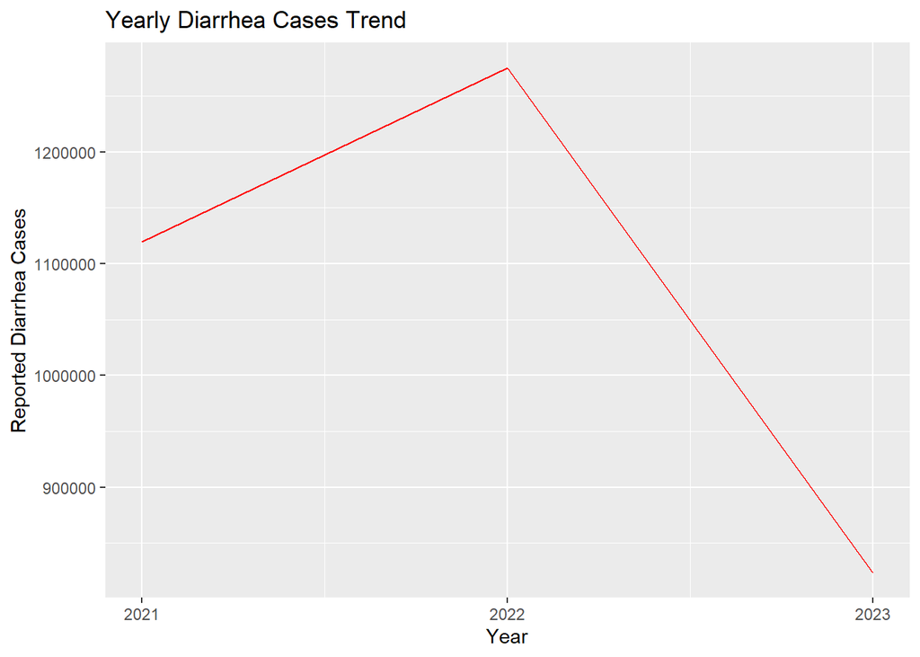

```r
# Create a line plot using ggplot2
line_plot <- ggplot(yearly_diarrhea_cases, aes(x = year, y = reported_diarrhea_cases)) +
  geom_line(color="red") +
  labs(x = "Year", y = "Reported Diarrhea Cases", title = "Yearly Diarrhea Cases Trend") +
   scale_x_continuous(breaks = unique(yearly_diarrhea_cases$year), labels = unique(yearly_diarrhea_cases$year))

# Display the line plot
print(line_plot)
```

### Dewormed Case

```r
Total_Dewormed_Per_County <- analysis_data %>%
  group_by(county) %>%
  select(county, Total_Dewormed) %>%
  mutate(dewormed=sum(Total_Dewormed)) %>%
  select(-Total_Dewormed) %>%
  arrange(desc(dewormed)) %>%
  top_n(10) %>%
  distinct(dewormed, .keep_all = FALSE)
print(Total_Dewormed_Per_County)
```

```
## # A tibble: 44 × 2
## # Groups:   county [44]
##    county          dewormed
##    <chr>              <dbl>
##  1 Nairobi County   2019461
##  2 Nakuru County     794575
##  3 Kilifi County     786594
##  4 Narok County      682578
##  5 Kiambu County     552724
##  6 Kwale County      544232
##  7 Turkana County    538946
##  8 Machakos County   518546
##  9 Kajiado County    509732
## 10 Meru County       488199
## # … with 34 more rows
```

Nairobi County has dewormed 2019461 children between 2021-Jan to 2023-June. We can however, break down our analysis to obtain insights on the number of children that have been dewormed in 2023 thus far.

```r
# Number of children whom have been dewormed per county in 2023
Total_Dewormed_Per_County_2023 <- analysis_data %>%
  filter(date_period >='2023-01-01') %>%
  group_by(county) %>%
  select(county, Total_Dewormed) %>%
  mutate(dewormed_2023=sum(Total_Dewormed)) %>%
  select(-Total_Dewormed) %>%
  arrange(desc(dewormed_2023)) %>%
  top_n(10) %>%
  distinct(dewormed_2023, .keep_all = TRUE)
top_10_dewormed_counties_2023 = head(Total_Dewormed_Per_County_2023, 10)

print(top_10_dewormed_counties_2023)
```

```
## # A tibble: 10 × 2
## # Groups:   county [10]
##    county          dewormed_2023
##    <chr>                   <dbl>
##  1 Nairobi County         511496
##  2 Meru County            202761
##  3 Kajiado County         165621
##  4 Narok County           152490
##  5 Nakuru County          148239
##  6 Kitui County           147440
##  7 Machakos County        137256
##  8 Makueni County         137154
##  9 Kiambu County          134893
## 10 Kilifi County          128258
```

```r
# print the counties with the lowest number of children dewormed
county_least_dewormed <- tail(Total_Dewormed_Per_County_2023, 3)
print(county_least_dewormed)
```

```
## # A tibble: 3 × 2
## # Groups:   county [3]
##   county             dewormed_2023
##   <chr>                      <dbl>
## 1 Uasin Gishu County          7878
## 2 Nyandarua County            7387
## 3 Bomet County                2011
```

## Correlation Analysis

In this section we aim at finding out the association between the numeric variables in the dataset.

Correlation values lies between -1 and 1. A negative correlation value indicates an inverse association, that is, an increase in one factor likely leads to a decrease in the other, a 0 correlation value indicates no relationship between the variables, and a positive correlation value indicates that an increase in one factor will likely lead to an increase in the other.

```r
# we'll calculate the correlations and use ggcorrplot() function to plot the association
library(ggcorrplot)

# select numeric columns only
corr_data <-  dplyr::select_if(analysis_data, is.numeric)

# calculate the correlation
corr_matrix <-cor(corr_data)

corr_matrix
```

```
##                           Total_Dewormed Acute_Malnutrition
## Total_Dewormed                1.00000000         0.08014465
## Acute_Malnutrition            0.08014465         1.00000000
## stunted_6_to_23_mths          0.30946499         0.09823035
## stunted_0_to_6_mths           0.46039717         0.07525906
## stunted_24_to_59_mths         0.17500396         0.23739614
## Diarrhea_cases                0.32314550         0.24506553
## underweight_0_to_6_mths       0.34466060         0.13018643
## underweight_6_to_23_mths      0.34375231         0.30601721
## underweight_24_to_59_mths     0.07584220         0.44006748
##                           stunted_6_to_23_mths stunted_0_to_6_mths
## Total_Dewormed                      0.30946499          0.46039717
## Acute_Malnutrition                  0.09823035          0.07525906
## stunted_6_to_23_mths                1.00000000          0.55318434
## stunted_0_to_6_mths                 0.55318434          1.00000000
## stunted_24_to_59_mths               0.45381318          0.20162307
## Diarrhea_cases                      0.63748682          0.46591258
## underweight_0_to_6_mths             0.69172928          0.62900314
## underweight_6_to_23_mths            0.80521446          0.53242767
## underweight_24_to_59_mths           0.27855404          0.07009893
##                           stunted_24_to_59_mths Diarrhea_cases
## Total_Dewormed                        0.1750040      0.3231455
## Acute_Malnutrition                    0.2373961      0.2450655
## stunted_6_to_23_mths                  0.4538132      0.6374868
## stunted_0_to_6_mths                   0.2016231      0.4659126
## stunted_24_to_59_mths                 1.0000000      0.3909895
## Diarrhea_cases                        0.3909895      1.0000000
## underweight_0_to_6_mths               0.2305176      0.6679738
## underweight_6_to_23_mths              0.6110149      0.7290982
## underweight_24_to_59_mths             0.7100677      0.3518845
##                           underweight_0_to_6_mths underweight_6_to_23_mths
## Total_Dewormed                         0.34466060                0.3437523
## Acute_Malnutrition                     0.13018643                0.3060172
## stunted_6_to_23_mths                   0.69172928                0.8052145
## stunted_0_to_6_mths                    0.62900314                0.5324277
## stunted_24_to_59_mths                  0.23051760                0.6110149
## Diarrhea_cases                         0.66797376                0.7290982
## underweight_0_to_6_mths                1.00000000                0.7195965
## underweight_6_to_23_mths               0.71959646                1.0000000
## underweight_24_to_59_mths              0.06908767                0.5540450
##                           underweight_24_to_59_mths
## Total_Dewormed                           0.07584220
## Acute_Malnutrition                       0.44006748
## stunted_6_to_23_mths                     0.27855404
## stunted_0_to_6_mths                      0.07009893
## stunted_24_to_59_mths                    0.71006767
## Diarrhea_cases                           0.35188454
## underweight_0_to_6_mths                  0.06908767
## underweight_6_to_23_mths                 0.55404504
## underweight_24_to_59_mths                1.00000000
```

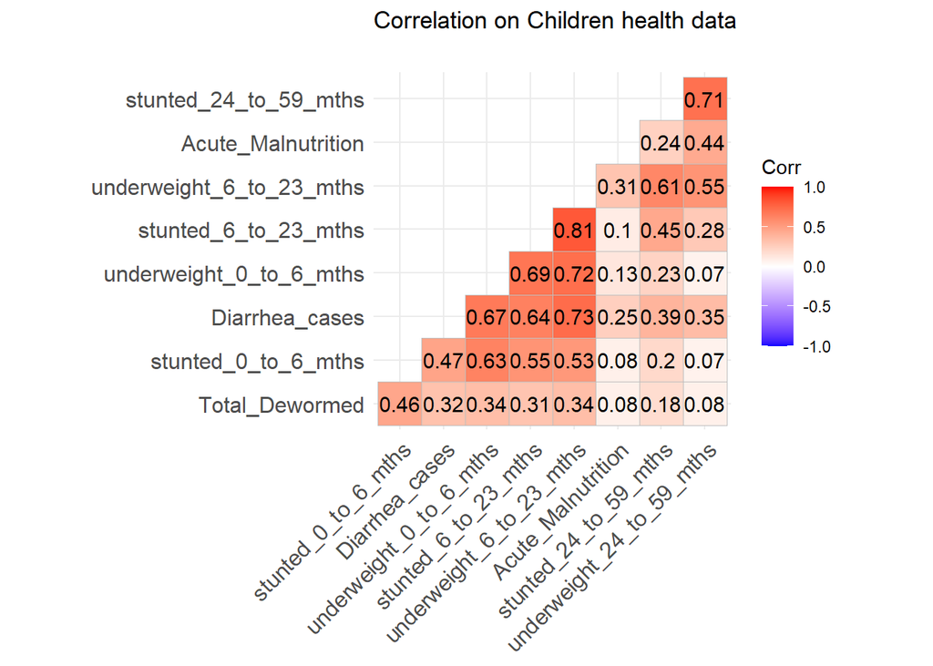

```r
# Plot the corr_matrix
cor_plot <- ggcorrplot(corr_matrix,
  hc.order = TRUE,
  type = "lower",
  lab = TRUE) + labs(title = "Correlation on Children health data", subtitle = "  ")

cor_plot
```

Using the correlation values we can obtain the association between two variables. Taking for instance the correlation value between diarrhea cases and acute malnutrition (0.25) indicates that there is a positive correlation between the two.

However, correlation does not necessarily mean causation. We therefore carried out a regression analysis to study if total number of children dewormed, number of children with acute malnutrition had a significant impact on the number of diarrhea cases reported.

### Regression analysis

Using multiple linear regression, we can find out the relationship between one dependent variable and two or more independent variables.

In this analysis, the dependent variable is the number of diarrhea cases, and the independent variables include total number of children dewormed, number of children with acute malnutrition.

```r
# use lm() function to carry out regression analysis
model <- lm(Diarrhea_cases~Acute_Malnutrition+Total_Dewormed, analysis_data)

summary(model)
```

```
##
## Call:
## lm(formula = Diarrhea_cases ~ Acute_Malnutrition + Total_Dewormed,
##     data = analysis_data)
##
## Residuals:
##     Min      1Q  Median      3Q     Max
## -8562.3 -1311.5  -558.2   586.0 11435.0
##
## Coefficients:
##                     Estimate Std. Error t value Pr(>|t|)
## (Intercept)        2.499e+03  7.802e+01  32.035  < 2e-16 ***
## Acute_Malnutrition 1.985e+00  2.570e-01   7.722 2.67e-14 ***
## Total_Dewormed     2.527e-02  2.363e-03  10.694  < 2e-16 ***
## ---
## Signif. codes:  0 '***' 0.001 '**' 0.01 '*' 0.05 '.' 0.1 ' ' 1
##
## Residual standard error: 2125 on 1045 degrees of freedom
## Multiple R-squared:  0.1528, Adjusted R-squared:  0.1511
## F-statistic: 94.21 on 2 and 1045 DF,  p-value: < 2.2e-16
```

From the regression model result, acute malnutrition seems to have a significant impact on the number of diarrhea cases reported (p-value = 2.67-14). An increase in malnutrition cases increases the number of reported diarrhea cases by 1.985e+00.

In addition, it is discovered that the number of children dewormed in a given region significantly impacted the total number of diarrhea cases the region reported (p-value = <2e-16).